# Example simulation

Marcin Kierczak

10/12/2020

### Introduction

In this document, I show example simulation workflow using implemented functions. The main idea is to take a real dataset and, based on the actual genotypes at a locus (or more loci), simulate phenotype. Loci are selected in random fashion, but they have certain desired characteristics, namely they fall into a certain minor-allele frequency (maf) bin and they have given effect sizes (also related to the maf).

In this document, we will use datasets supplied by the `GenABEL` package.

```r
library('GenABEL')
library('SKAT')
library('here')
library('tidyverse')
```

```r
source(here('/R/get_effects.R'))
source(here('/R/plot_effects.R'))
source(here('/R/impute_G.R'))
source(here('/R/get_genotypes.R'))
source(here('/R/fix_allele_encoding.R'))
source(here('/R/tibble_to_raw_genotypes.R'))
source(here('/R/tibble_to_gwaa.R'))

plot_pheno <- function(y, G) {
  data <- tibble(id = rownames(G), y = y)
  ggplot(data, mapping = aes(x=y)) + geom_histogram() + theme_bw()
}
```

After this initial setup, we can load the actual data and look at its dimensions:

```r
data(srdta)
nids(srdta)
```

```
## [1] 2500
```

```r
nsnps(srdta)
```

```
## [1] 833
```

### Extracting and preparing data

In this step, we will extract marker summary data, compute reference allele frequency from allele counts and compute minor allele frequency.

```r
tmp <- summary(srdta@gtdata)
raf <- ((2 * tmp$P.22) + tmp$P.12) / (2 * tmp$NoMeasured) # reference allele frequency
maf <- pmin(raf, 1 - raf)
names(maf) <- colnames(srdta@gtdata)
```

Above, we made sure we are getting the actual minor allele frequency, not the arbitrary reference allele frequency as done in GenABEL.

### Modelling effects for common markers

Now, we are ready to simulate some effects based on, in this case, $N = 2$ randomly selected loci with $maf > 0.05$ (common variants). We say, the effect of each allele should be proportional to its maf and this relationship is given by the ${\beta}$ distribution with shape parameters set to `c(0.1, 0.1)`. We will not model any markers with negative effect here.

```r
# Get effects for common alleles
common <- get_effects(maf = maf, thr = 0.05,
                              N = 2,
                              shape12 = c(.1,.1),
                              rare = F,
                              frac_negative = 0)
```

We can have a quick look at wgat the `get_effects` function has returned.

```r
str(common)
```

```
## List of 2
##  $ marker_idx: Named int [1:2] 729 790
##   ..- attr(*, "names")= chr [1:2] "rs8028" "rs8703"
##  $ effects   : Named num [1:2] 0.241 0.179
##   ..- attr(*, "names")= chr [1:2] "rs8028" "rs8703"
```

```r
common
```

```
## $marker_idx
## rs8028 rs8703
##    729    790
##
## $effects
##    rs8028    rs8703
## 0.2412181 0.1789445
```

We can see it is a list with two elements: marker indices (and names) and their effects.

### Extracting genotypes matrix

Now, we will get the actual genotypes at the loci used for simulation. We than convert them to *double* so that the genotypes matrix $G$ contains allele counts. We need to make sure that the genotypes matrix contains the minor allele count and not some other reference allele count which we do by calling the `fix_allele_encoding` function. Finally, we impute missing genotypes based on maf value and following the Hardy-Weinberg principle using the `impute_G` function.

```r
genos_common <- srdta@gtdata[,common$marker_idx]
      G_comm <- as.double(genos_common) %>%
      fix_allele_encoding() %>%
      impute_G(maf = maf[common$marker_idx])
```

Let’s gave a look at the genotypes matrix (here, for the 5 first individuals):

```r
G_comm[1:5, ]
```

```
##    rs8028 rs8703
## p1      2      0
## p2      0      1
## p3      2      2
## p4      0      2
## p5      1      1
```

Indeed, we see that the matrix contains minor allele counts at each locus and for every individual. This is exactly what we do need to simulate our phenotypes.

### Simulating phenotypes

In order to simulate phenotypes, one can use standard linear model $y = X\beta + \epsilon$ equation with $X = G$. We have everything we need:

- the genotypes matrix $G$,
- the effects vector $\beta$ and
- the Gaussian error term $\epsilon \sim \mathcal{N}(0, 1)$

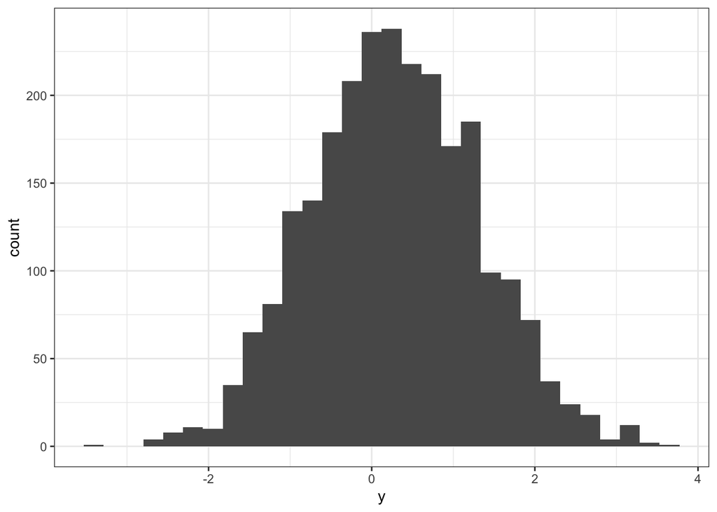

```r
y_comm <- G_comm %*% common$effects + rnorm(n = dim(G_comm)[1], mean = 0, sd = 1)
plot_pheno(y_comm, G_comm)
```

### GWAS on the simulated phenotype

Now, in order to test whether it works, we need to inject the simulated phenotype to the GenABEL *gwaa.data* object:

```r
srdta@phdata[,'qt1'] <- y_comm
```

After having done this, we can perform a regular GWAS:

```r
qt <- qtscore(qt1 ~ sex, data = srdta)
```

And, finally, plot the results making markers used for simulation easily distinguishable by coloring them red.

```r
plot(qt, las=1, cex.axis = .7, col = 'darkgreen', cex=.5)
grid()
col <- as.numeric(common$effects > 0)
col[col == 1] <- 'red'
col[col == 0] <- 'blue'
(simulated <- names(common$effects))
```

```
## [1] "rs8028" "rs8703"
```

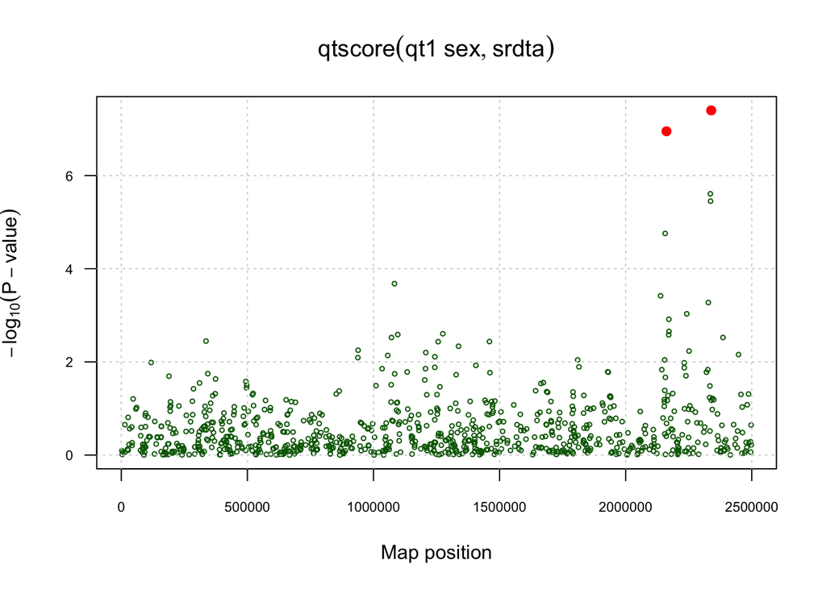

```r
points(qt[simulated,]$Position, -log10(qt[simulated,]$P1df), col=col, pch=19)
```

### SKATO on the simulated phenotype

Now, we can proceed to testing SKATO’s behavior at different parameters. First, we will create a special function that will let us simulate effect based on a number of rare alleles and directly test SKATO on these data.

```r
library(SKAT)

run_SKAT_test <- function(N_trials = 10, N_markers = 20, maf, data, shape12 = c(1,25), frac_negative = .2) {
  result <- rep(NA, times = N_trials)
    i <- 1
    for (i in 1:N_trials) {
    rare <- get_effects(maf = maf, thr = 0.01,
                      N = N_markers,
                      shape12 = c(1,25),
                      rare = T,
                      frac_negative = frac_negative)
    genos_rare <- data@gtdata[,rare$marker_idx]
    G_rare <- as.double(genos_rare) %>% fix_allele_encoding() %>% impute_G(maf = maf[rare$marker_idx])
    y_rare <- G_rare %*% rare$effects + rnorm(n = dim(G_rare)[1], mean = 0, sd = 1)
    srdta@phdata[,'qt1'] <- y_rare
    skat_null_model <- SKAT_Null_Model(qt1~sex, data = srdta@phdata)
    skat_model <- SKAT(G_rare, skat_null_model, method = 'SKATO')
    result[i] <- skat_model$p.value
    i <- i + 1
  }
  return(result)
}
```

Now, we can define our hyperparameters space:

```r
N_trials <- 10
N_markers <- 20
experiment <- expand.grid(beta1 = c(1), beta2 = c(1, 10, 20, 25), frac_neg = c(.2))

result <- matrix(NA, nrow = dim(experiment)[1], ncol = N_trials)
for (i in 1:dim(experiment)[1]) {
  pvals <- run_SKAT_test(N = N_trials,
                         N_markers = N_markers,
                         maf = maf,
                         data = srdta,
                         shape12 = c(experiment$beta1[i], experiment$beta2[i]),
                         frac_negative = experiment$frac_neg[i])
  result[i, ] <- pvals
}
```

Finally, we can do some plotting:

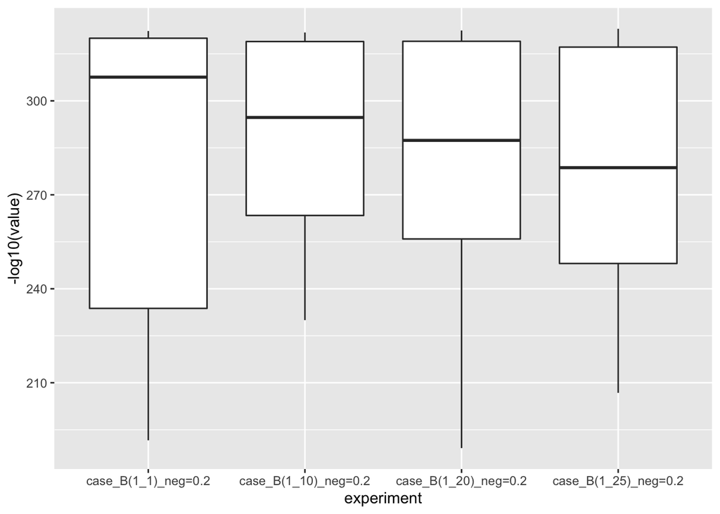

```r
label <- paste0("case_B(",experiment$beta1,"_",experiment$beta2,")_neg=",experiment$frac_neg)
experiment_data <- data.frame(experiment=label, result)
experiment_data %>% as_tibble() %>% replace(. == 0, 1e-320) %>%
  pivot_longer(cols = -1, names_to = 'trial') %>%
  ggplot(mapping = aes(x = experiment, y = -log10(value), group=experiment)) + geom_boxplot()
```